# A3_2_641675

**Fernando Ariel Lozano Castillo**

Entrena un modelo de redes neuronales para clasificar los dígitos del 0 al 9, y muestra mediante gráficas el comportamiento del sistema a lo largo del entrenamiento.

**Para esto usare el codigo base de la presentación y más adelante en el punto 5 al agregar las mejoras al programa base.**

Empecemos importando librerias y base de datos

```python
import numpy as np
import matplotlib.pyplot as plt
import tensorflow as tf
import cv2
from tensorflow.keras.datasets import mnist
(train_images, train_labels), (test_images, test_labels) = mnist.load_data()
```

```
Downloading data from https://storage.googleapis.com/tensorflow/tf-keras-datasets/mnist.npz
11490434/11490434 ━━━━━━━━━━━━━━━━━━━━ 0s 0us/step
```

Ahora prosigamos con la construcción de feedforward neural network

```python
# Import keras modules
from tensorflow.keras.models import Sequential
from tensorflow.keras.layers import Flatten, Dense

# Create simple feedforward neural network
model = Sequential()
# Input Layer: Flatten the 28x28 image data
model.add(Flatten(input_shape=(28, 28)))

# Hidden Layer 1: 128 units with ReLU activation
model.add(Dense(128, activation='relu'))
# Hidden Layer 2: 64 units with ReLU activation
model.add(Dense(64, activation='relu'))
# Output Layer: 10 units for 10 classes with softmax activation for probability distribution
model.add(Dense(10, activation='softmax'))
```

Ahora para el entrenamiento usare un optimizador y early stop

```python
# Specify optimizer
opt = tf.keras.optimizers.Adam(learning_rate=0.001)
model.compile(optimizer=opt, loss='sparse_categorical_crossentropy', metrics=['accuracy'])
model.summary()

# Create early stopping callback
from tensorflow.keras.callbacks import EarlyStopping
early_stop = EarlyStopping(monitor='val_accuracy', patience=10, restore_best_weights=True)
```

```
Model: "sequential"
```

```
┏━━━━━━━━━━━━━━━━━━━━━━━━━━━━━━━━━┳━━━━━━━━━━━━━━━━━━━━━━━━┳━━━━━━━━━━━━━━━┓
┃ Layer (type)                    ┃ Output Shape           ┃       Param # ┃
┡━━━━━━━━━━━━━━━━━━━━━━━━━━━━━━━━━╇━━━━━━━━━━━━━━━━━━━━━━━━╇━━━━━━━━━━━━━━━┩
│ flatten (Flatten)               │ (None, 784)            │             0 │
├─────────────────────────────────┼────────────────────────┼───────────────┤
│ dense (Dense)                   │ (None, 128)            │       100,480 │
├─────────────────────────────────┼────────────────────────┼───────────────┤
│ dense_1 (Dense)                 │ (None, 64)             │         8,256 │
├─────────────────────────────────┼────────────────────────┼───────────────┤
│ dense_2 (Dense)                 │ (None, 10)             │           650 │
└─────────────────────────────────┴────────────────────────┴───────────────┘
```

```
 Total params: 109,386 (427.29 KB)
```

```
 Trainable params: 109,386 (427.29 KB)
```

```
 Non-trainable params: 0 (0.00 B)
```

```python
#Entrenamiento
history = model.fit(train_images, train_labels, epochs=50, validation_split=0.4, batch_size=32, callbacks=[early_stop])
```

```
1125/1125 ━━━━━━━━━━━━━━━━━━━━ 7s 5ms/step - accuracy: 0.7666 - loss: 5.6787 - val_accuracy: 0.8836 - val_loss: 0.5232
1125/1125 ━━━━━━━━━━━━━━━━━━━━ 4s 3ms/step - accuracy: 0.8979 - loss: 0.4114 - val_accuracy: 0.9013 - val_loss: 0.4061
1125/1125 ━━━━━━━━━━━━━━━━━━━━ 4s 3ms/step - accuracy: 0.9312 - loss: 0.2552 - val_accuracy: 0.9267 - val_loss: 0.2718
1125/1125 ━━━━━━━━━━━━━━━━━━━━ 6s 4ms/step - accuracy: 0.9431 - loss: 0.2031 - val_accuracy: 0.9408 - val_loss: 0.2315
1125/1125 ━━━━━━━━━━━━━━━━━━━━ 5s 4ms/step - accuracy: 0.9550 - loss: 0.1619 - val_accuracy: 0.9426 - val_loss: 0.2426
1125/1125 ━━━━━━━━━━━━━━━━━━━━ 5s 4ms/step - accuracy: 0.9598 - loss: 0.1386 - val_accuracy: 0.9500 - val_loss: 0.1946
1125/1125 ━━━━━━━━━━━━━━━━━━━━ 5s 4ms/step - accuracy: 0.9648 - loss: 0.1235 - val_accuracy: 0.9488 - val_loss: 0.1964
1125/1125 ━━━━━━━━━━━━━━━━━━━━ 5s 4ms/step - accuracy: 0.9683 - loss: 0.1076 - val_accuracy: 0.9486 - val_loss: 0.2227
1125/1125 ━━━━━━━━━━━━━━━━━━━━ 6s 5ms/step - accuracy: 0.9715 - loss: 0.0998 - val_accuracy: 0.9552 - val_loss: 0.1770
1125/1125 ━━━━━━━━━━━━━━━━━━━━ 9s 4ms/step - accuracy: 0.9717 - loss: 0.0950 - val_accuracy: 0.9560 - val_loss: 0.1976
1125/1125 ━━━━━━━━━━━━━━━━━━━━ 5s 4ms/step - accuracy: 0.9778 - loss: 0.0802 - val_accuracy: 0.9565 - val_loss: 0.2001
1125/1125 ━━━━━━━━━━━━━━━━━━━━ 5s 4ms/step - accuracy: 0.9772 - loss: 0.0796 - val_accuracy: 0.9515 - val_loss: 0.2436
1125/1125 ━━━━━━━━━━━━━━━━━━━━ 5s 4ms/step - accuracy: 0.9776 - loss: 0.0860 - val_accuracy: 0.9616 - val_loss: 0.1759
1125/1125 ━━━━━━━━━━━━━━━━━━━━ 4s 3ms/step - accuracy: 0.9833 - loss: 0.0605 - val_accuracy: 0.9618 - val_loss: 0.1714
1125/1125 ━━━━━━━━━━━━━━━━━━━━ 6s 4ms/step - accuracy: 0.9847 - loss: 0.0540 - val_accuracy: 0.9607 - val_loss: 0.1796
1125/1125 ━━━━━━━━━━━━━━━━━━━━ 4s 3ms/step - accuracy: 0.9832 - loss: 0.0589 - val_accuracy: 0.9533 - val_loss: 0.2463
1125/1125 ━━━━━━━━━━━━━━━━━━━━ 4s 3ms/step - accuracy: 0.9830 - loss: 0.0622 - val_accuracy: 0.9621 - val_loss: 0.2066
1125/1125 ━━━━━━━━━━━━━━━━━━━━ 6s 4ms/step - accuracy: 0.9845 - loss: 0.0560 - val_accuracy: 0.9657 - val_loss: 0.2050
1125/1125 ━━━━━━━━━━━━━━━━━━━━ 5s 4ms/step - accuracy: 0.9878 - loss: 0.0433 - val_accuracy: 0.9622 - val_loss: 0.2275
1125/1125 ━━━━━━━━━━━━━━━━━━━━ 5s 4ms/step - accuracy: 0.9825 - loss: 0.0696 - val_accuracy: 0.9634 - val_loss: 0.2362
1125/1125 ━━━━━━━━━━━━━━━━━━━━ 4s 3ms/step - accuracy: 0.9868 - loss: 0.0548 - val_accuracy: 0.9650 - val_loss: 0.2319
1125/1125 ━━━━━━━━━━━━━━━━━━━━ 5s 4ms/step - accuracy: 0.9878 - loss: 0.0467 - val_accuracy: 0.9604 - val_loss: 0.2714
1125/1125 ━━━━━━━━━━━━━━━━━━━━ 4s 4ms/step - accuracy: 0.9875 - loss: 0.0463 - val_accuracy: 0.9629 - val_loss: 0.2743
1125/1125 ━━━━━━━━━━━━━━━━━━━━ 4s 3ms/step - accuracy: 0.9874 - loss: 0.0481 - val_accuracy: 0.9595 - val_loss: 0.2696
1125/1125 ━━━━━━━━━━━━━━━━━━━━ 6s 4ms/step - accuracy: 0.9893 - loss: 0.0408 - val_accuracy: 0.9632 - val_loss: 0.2822
1125/1125 ━━━━━━━━━━━━━━━━━━━━ 6s 4ms/step - accuracy: 0.9872 - loss: 0.0469 - val_accuracy: 0.9642 - val_loss: 0.2593
1125/1125 ━━━━━━━━━━━━━━━━━━━━ 4s 4ms/step - accuracy: 0.9890 - loss: 0.0421 - val_accuracy: 0.9622 - val_loss: 0.2783
1125/1125 ━━━━━━━━━━━━━━━━━━━━ 5s 5ms/step - accuracy: 0.9895 - loss: 0.0419 - val_accuracy: 0.9657 - val_loss: 0.2938
```

**Especifica la exactitud del modelo tanto en entrenamiento como en validación**

```python
# Obtener la mejor época según EarlyStopping
stopped_epoch = early_stop.stopped_epoch
best_epoch = stopped_epoch - early_stop.patience

# Obtener mejores exactitudes de entrenamiento y validación
final_train_acc = history.history['accuracy'][best_epoch]
final_val_acc = history.history['val_accuracy'][best_epoch]

# Imprimir resultados de entrenamiento y validación
print(f"Mejor Exactitud en Entrenamiento: {final_train_acc:.4f}")
print(f"Mejor Exactitud en Validación: {final_val_acc:.4f}")

# Evaluar exactitud en el conjunto de prueba
test_loss, test_accuracy = model.evaluate(test_images, test_labels)
print(f"Exactitud en conjunto de prueba: {test_accuracy:.4f}")
```

```
Mejor Exactitud en Entrenamiento: 0.9837
Mejor Exactitud en Validación: 0.9657
313/313 ━━━━━━━━━━━━━━━━━━━━ 1s 3ms/step - accuracy: 0.9638 - loss: 0.1960
Exactitud en conjunto de prueba: 0.9667
```

**Ahora veamos las graficas**

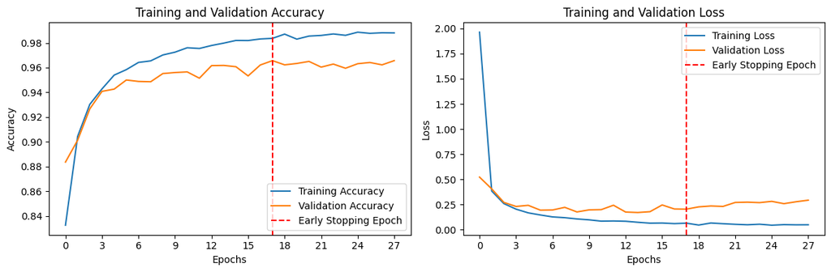

```python
from matplotlib.ticker import MaxNLocator
stopped_epoch = early_stop.stopped_epoch
best_epoch = stopped_epoch - early_stop.patience

plt.figure(figsize=(12, 4))

plt.subplot(1, 2, 1)
plt.plot(history.history['accuracy'], label='Training Accuracy')
plt.plot(history.history['val_accuracy'], label='Validation Accuracy')
plt.axvline(x=best_epoch, color='r', linestyle='--', label='Early Stopping Epoch')
plt.title('Training and Validation Accuracy')
plt.xlabel('Epochs')
plt.ylabel('Accuracy')
plt.gca().xaxis.set_major_locator(MaxNLocator(integer=True))  # Ensure integer values on x-axis
plt.legend()

plt.subplot(1, 2, 2)
plt.plot(history.history['loss'], label='Training Loss')
plt.plot(history.history['val_loss'], label='Validation Loss')
plt.axvline(x=best_epoch, color='r', linestyle='--', label='Early Stopping Epoch')
plt.title('Training and Validation Loss')
plt.xlabel('Epochs')
plt.ylabel('Loss')
plt.gca().xaxis.set_major_locator(MaxNLocator(integer=True))  # Ensure integer values on x-axis
plt.legend()

plt.tight_layout()
plt.show()
```

Genere 50 imágenes, 5 para cada dígito y use 10 hojas .Para tomar las fotos antes se Preprocesa las imágenes para que puedan ser evaluadas por el modelo .

```python
from IPython.display import display, Javascript
from google.colab.output import eval_js
from base64 import b64decode

def take_photo(filename='photo.jpg', quality=0.8):
    js = Javascript('''
        async function takePhoto(quality) {
            const div = document.createElement('div');
            const capture = document.createElement('button');
            capture.textContent = 'Capture';
            div.appendChild(capture);

            const video = document.createElement('video');
            video.style.display = 'block';
            const stream = await navigator.mediaDevices.getUserMedia({video: true});

            document.body.appendChild(div);
            div.appendChild(video);
            video.srcObject = stream;
            await video.play();

            google.colab.output.setIframeHeight(document.documentElement.scrollHeight, true);

            await new Promise((resolve) => {
                capture.onclick = resolve;
            });

            const canvas = document.createElement('canvas');
            canvas.width = video.videoWidth;
            canvas.height = video.videoHeight;
            canvas.getContext('2d').drawImage(video, 0, 0);

            stream.getVideoTracks()[0].stop();
            div.remove();
            return canvas.toDataURL('image/jpeg', quality);
        }
    ''')

    display(js)
    data = eval_js('takePhoto({})'.format(quality))
    binary = b64decode(data.split(',')[1])

    with open(filename, 'wb') as f:
        f.write(binary)

    return filename
```

```python
take_photo()
```

```
'photo.jpg'
```

Despues de tomar la foto. preprocesamos y hacemos la prediccion

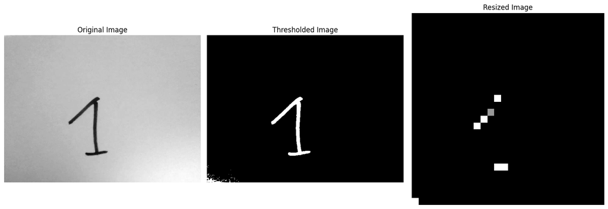

```python
import cv2
import numpy as np
import matplotlib.pyplot as plt

# Load the image in grayscale
image = cv2.imread('photo.jpg', cv2.IMREAD_GRAYSCALE)

# Thresholding
_, thresh = cv2.threshold(image, 105, 255, cv2.THRESH_BINARY_INV)

# Resize the image to 28x28 pixels
resized = cv2.resize(thresh, (28, 28))



# Display the images side by side
fig, axes = plt.subplots(1, 3, figsize=(15, 5))
# Original Image
axes[0].imshow(image, cmap='gray')
axes[0].set_title('Original Image')
axes[0].axis('off')
# Thresholded Image
axes[1].imshow(thresh, cmap='gray')
axes[1].set_title('Thresholded Image')
axes[1].axis('off')
# Resized Image
axes[2].imshow(resized, cmap='gray')
axes[2].set_title('Resized Image')
axes[2].axis('off')
plt.tight_layout()
plt.show()
```

Ahora la prediccion

```python
# Reshape the image for model compatibility (batch size, height, width, channels)
input_image = resized.reshape(1, 28, 28, 1)
# Use the mode's predict method
prediction = model.predict(input_image)
predicted_label = np.argmax(prediction)
# Display the result
print("Digit | Probability")
print("-------------------")
for i, prob in enumerate(prediction[0]):
    print(f"  {i}   |   {prob:.5f}")
print(f"The predicted digit is: {predicted_label}")
```

```
1/1 ━━━━━━━━━━━━━━━━━━━━ 0s 31ms/step
Digit | Probability
-------------------
  0   |   0.05631
  1   |   0.02328
  2   |   0.22917
  3   |   0.10029
  4   |   0.11787
  5   |   0.13231
  6   |   0.10053
  7   |   0.07176
  8   |   0.09422
  9   |   0.07426
The predicted digit is: 2
```

Conclusion: El modelo no es el mejor, de los numeros del 0 al 9 solo predijo correctamente el 2 3 4 y 9. El resto de los numeros decia que eran 2,5,8, y en su mayoria 3. Lo que yo creo que pueda ser errores son:

1. Relacionado a la foto(iluminacion, ancho de los trazos en los numeros)
2. Tal vez el valor de treshold de 105, no sea el adecuado, al ir al punto 5 cambiare el valor.
3. La resized image nunca fue completa o eran muy pocos cuadros blancos
4. Tal vez no fue suficientes capas y/o el optimizar utilizado.
5. Tal vez si un overfitting entonces ver que puedo haccer para disminuirlo

# Nuevo Modelo

Ahora que ya probamos el modelo base y que errores tiene, hare un nuevo modelo con modificaciones que estaran entre ##########################################

Codigo ########################################

Ahora a entrenar el nuevo modelo

```python
from tensorflow.keras.models import Sequential
from tensorflow.keras.layers import Dense, Flatten, Dropout, BatchNormalization
from tensorflow.keras.optimizers import Adam
from tensorflow.keras.callbacks import EarlyStopping
from sklearn.utils import class_weight
import numpy as np

# Crear el modelo secuencial
MOD2 = Sequential(name="MOD2")

# Capa de entrada
MOD2.add(Flatten(input_shape=(28, 28)))

###  PRIMER CAMBIO  Agreue mas capas y unas con batch y drop out
###########################################################################################33
# Capas ocultas con BatchNorm, ReLU y Dropout
MOD2.add(Dense(256, activation='relu'))
MOD2.add(BatchNormalization())
MOD2.add(Dropout(0.3))
MOD2.add(Dense(128, activation='relu'))
MOD2.add(Dense(64, activation='relu'))
MOD2.add(BatchNormalization())
MOD2.add(Dense(32, activation='relu'))

MOD2.add(Dropout(0.2))
###########################################################################################

# Capa de salida
MOD2.add(Dense(10, activation='softmax'))

# Compilar el modelo
opt = Adam(learning_rate=0.001)
MOD2.compile(optimizer=opt,
              loss='sparse_categorical_crossentropy',
              metrics=['accuracy'])

# Mostrar el resumen del modelo
MOD2.summary()
```

```
Model: "MOD2"
```

```
┏━━━━━━━━━━━━━━━━━━━━━━━━━━━━━━━━━┳━━━━━━━━━━━━━━━━━━━━━━━━┳━━━━━━━━━━━━━━━┓
┃ Layer (type)                    ┃ Output Shape           ┃       Param # ┃
┡━━━━━━━━━━━━━━━━━━━━━━━━━━━━━━━━━╇━━━━━━━━━━━━━━━━━━━━━━━━╇━━━━━━━━━━━━━━━┩
│ flatten_2 (Flatten)             │ (None, 784)            │             0 │
├─────────────────────────────────┼────────────────────────┼───────────────┤
│ dense_8 (Dense)                 │ (None, 256)            │       200,960 │
├─────────────────────────────────┼────────────────────────┼───────────────┤
│ batch_normalization_2           │ (None, 256)            │         1,024 │
│ (BatchNormalization)            │                        │               │
├─────────────────────────────────┼────────────────────────┼───────────────┤
│ dropout_2 (Dropout)             │ (None, 256)            │             0 │
├─────────────────────────────────┼────────────────────────┼───────────────┤
│ dense_9 (Dense)                 │ (None, 128)            │        32,896 │
├─────────────────────────────────┼────────────────────────┼───────────────┤
│ dense_10 (Dense)                │ (None, 64)             │         8,256 │
├─────────────────────────────────┼────────────────────────┼───────────────┤
│ batch_normalization_3           │ (None, 64)             │           256 │
│ (BatchNormalization)            │                        │               │
├─────────────────────────────────┼────────────────────────┼───────────────┤
│ dense_11 (Dense)                │ (None, 32)             │         2,080 │
├─────────────────────────────────┼────────────────────────┼───────────────┤
│ dropout_3 (Dropout)             │ (None, 32)             │             0 │
├─────────────────────────────────┼────────────────────────┼───────────────┤
│ dense_12 (Dense)                │ (None, 10)             │           330 │
└─────────────────────────────────┴────────────────────────┴───────────────┘
```

```
 Total params: 245,802 (960.16 KB)
```

```
 Trainable params: 245,162 (957.66 KB)
```

```
 Non-trainable params: 640 (2.50 KB)
```

```python
### SEGUNDO CAMBIO       Agregue balance de clases que afecta al entrenamiento y   reduje la patience a 5
#############################################################################
# Calcular el balance de clases
class_weights = class_weight.compute_class_weight(
    class_weight='balanced',
    classes=np.unique(train_labels),
    y=train_labels
)
class_weights = dict(enumerate(class_weights))
#############################################################################
# Definir EarlyStopping
early_stop = EarlyStopping(monitor='val_accuracy', patience=5, restore_best_weights=True)

# Entrenar el modelo
history = MOD2.fit(
    train_images, train_labels,
    epochs=50,
    validation_split=0.4,
    batch_size=32,
    callbacks=[early_stop],
    class_weight=class_weights  # <- Aquí aplicamos el balanceo de clases
)
```

```
1125/1125 ━━━━━━━━━━━━━━━━━━━━ 15s 11ms/step - accuracy: 0.7502 - loss: 0.8063 - val_accuracy: 0.9426 - val_loss: 0.2028
1125/1125 ━━━━━━━━━━━━━━━━━━━━ 13s 12ms/step - accuracy: 0.9219 - loss: 0.2668 - val_accuracy: 0.9578 - val_loss: 0.1443
1125/1125 ━━━━━━━━━━━━━━━━━━━━ 19s 10ms/step - accuracy: 0.9396 - loss: 0.2080 - val_accuracy: 0.9592 - val_loss: 0.1499
1125/1125 ━━━━━━━━━━━━━━━━━━━━ 11s 10ms/step - accuracy: 0.9499 - loss: 0.1735 - val_accuracy: 0.9631 - val_loss: 0.1311
1125/1125 ━━━━━━━━━━━━━━━━━━━━ 11s 10ms/step - accuracy: 0.9542 - loss: 0.1559 - val_accuracy: 0.9670 - val_loss: 0.1261
1125/1125 ━━━━━━━━━━━━━━━━━━━━ 22s 11ms/step - accuracy: 0.9577 - loss: 0.1437 - val_accuracy: 0.9693 - val_loss: 0.1181
1125/1125 ━━━━━━━━━━━━━━━━━━━━ 13s 11ms/step - accuracy: 0.9638 - loss: 0.1226 - val_accuracy: 0.9711 - val_loss: 0.1172
1125/1125 ━━━━━━━━━━━━━━━━━━━━ 18s 9ms/step - accuracy: 0.9635 - loss: 0.1205 - val_accuracy: 0.9708 - val_loss: 0.1198
1125/1125 ━━━━━━━━━━━━━━━━━━━━ 10s 9ms/step - accuracy: 0.9663 - loss: 0.1150 - val_accuracy: 0.9697 - val_loss: 0.1250
1125/1125 ━━━━━━━━━━━━━━━━━━━━ 20s 9ms/step - accuracy: 0.9719 - loss: 0.0956 - val_accuracy: 0.9715 - val_loss: 0.1165
1125/1125 ━━━━━━━━━━━━━━━━━━━━ 10s 9ms/step - accuracy: 0.9684 - loss: 0.1085 - val_accuracy: 0.9730 - val_loss: 0.1260
1125/1125 ━━━━━━━━━━━━━━━━━━━━ 20s 9ms/step - accuracy: 0.9726 - loss: 0.0929 - val_accuracy: 0.9739 - val_loss: 0.1184
1125/1125 ━━━━━━━━━━━━━━━━━━━━ 11s 10ms/step - accuracy: 0.9726 - loss: 0.0925 - val_accuracy: 0.9758 - val_loss: 0.1171
1125/1125 ━━━━━━━━━━━━━━━━━━━━ 20s 9ms/step - accuracy: 0.9747 - loss: 0.0840 - val_accuracy: 0.9758 - val_loss: 0.1254
1125/1125 ━━━━━━━━━━━━━━━━━━━━ 10s 9ms/step - accuracy: 0.9777 - loss: 0.0782 - val_accuracy: 0.9760 - val_loss: 0.1041
1125/1125 ━━━━━━━━━━━━━━━━━━━━ 21s 10ms/step - accuracy: 0.9783 - loss: 0.0746 - val_accuracy: 0.9768 - val_loss: 0.0901
1125/1125 ━━━━━━━━━━━━━━━━━━━━ 20s 10ms/step - accuracy: 0.9796 - loss: 0.0722 - val_accuracy: 0.9743 - val_loss: 0.1080
1125/1125 ━━━━━━━━━━━━━━━━━━━━ 10s 9ms/step - accuracy: 0.9777 - loss: 0.0733 - val_accuracy: 0.9742 - val_loss: 0.1113
1125/1125 ━━━━━━━━━━━━━━━━━━━━ 10s 9ms/step - accuracy: 0.9787 - loss: 0.0688 - val_accuracy: 0.9775 - val_loss: 0.0952
1125/1125 ━━━━━━━━━━━━━━━━━━━━ 11s 9ms/step - accuracy: 0.9790 - loss: 0.0699 - val_accuracy: 0.9757 - val_loss: 0.1047
1125/1125 ━━━━━━━━━━━━━━━━━━━━ 10s 9ms/step - accuracy: 0.9800 - loss: 0.0700 - val_accuracy: 0.9735 - val_loss: 0.1091
1125/1125 ━━━━━━━━━━━━━━━━━━━━ 11s 10ms/step - accuracy: 0.9794 - loss: 0.0679 - val_accuracy: 0.9778 - val_loss: 0.0951
1125/1125 ━━━━━━━━━━━━━━━━━━━━ 19s 9ms/step - accuracy: 0.9804 - loss: 0.0640 - val_accuracy: 0.9754 - val_loss: 0.1008
1125/1125 ━━━━━━━━━━━━━━━━━━━━ 9s 8ms/step - accuracy: 0.9811 - loss: 0.0612 - val_accuracy: 0.9774 - val_loss: 0.1022
1125/1125 ━━━━━━━━━━━━━━━━━━━━ 11s 10ms/step - accuracy: 0.9814 - loss: 0.0588 - val_accuracy: 0.9782 - val_loss: 0.1470
1125/1125 ━━━━━━━━━━━━━━━━━━━━ 21s 10ms/step - accuracy: 0.9823 - loss: 0.0599 - val_accuracy: 0.9786 - val_loss: 0.1413
1125/1125 ━━━━━━━━━━━━━━━━━━━━ 19s 9ms/step - accuracy: 0.9822 - loss: 0.0568 - val_accuracy: 0.9777 - val_loss: 0.1464
1125/1125 ━━━━━━━━━━━━━━━━━━━━ 11s 10ms/step - accuracy: 0.9828 - loss: 0.0584 - val_accuracy: 0.9775 - val_loss: 0.1283
1125/1125 ━━━━━━━━━━━━━━━━━━━━ 11s 10ms/step - accuracy: 0.9835 - loss: 0.0520 - val_accuracy: 0.9783 - val_loss: 0.1391
1125/1125 ━━━━━━━━━━━━━━━━━━━━ 20s 10ms/step - accuracy: 0.9858 - loss: 0.0483 - val_accuracy: 0.9796 - val_loss: 0.1501
1125/1125 ━━━━━━━━━━━━━━━━━━━━ 19s 9ms/step - accuracy: 0.9840 - loss: 0.0506 - val_accuracy: 0.9776 - val_loss: 0.1514
1125/1125 ━━━━━━━━━━━━━━━━━━━━ 11s 10ms/step - accuracy: 0.9850 - loss: 0.0520 - val_accuracy: 0.9792 - val_loss: 0.1456
1125/1125 ━━━━━━━━━━━━━━━━━━━━ 11s 10ms/step - accuracy: 0.9868 - loss: 0.0431 - val_accuracy: 0.9789 - val_loss: 0.1596
1125/1125 ━━━━━━━━━━━━━━━━━━━━ 12s 10ms/step - accuracy: 0.9841 - loss: 0.0513 - val_accuracy: 0.9784 - val_loss: 0.1494
1125/1125 ━━━━━━━━━━━━━━━━━━━━ 11s 10ms/step - accuracy: 0.9870 - loss: 0.0408 - val_accuracy: 0.9789 - val_loss: 0.1539
```

El codigo de la grafica puede que este diferente pero era porque tenia mis dudas si tal vez no se estaba graficando bien entonces le pedi a Deep Seek que checara si se estaba graficando el nuevo modelo y pues puede que haya hecho algun cambio menor al codigo de la grafica.

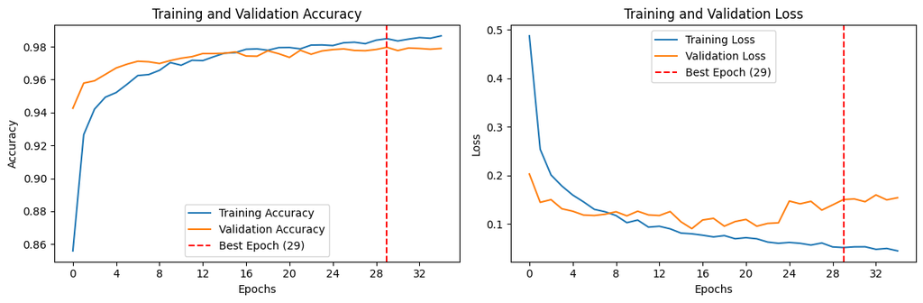

```python
from matplotlib.ticker import MaxNLocator

# Obtener la mejor época (ajustado para EarlyStopping)
stopped_epoch = early_stop.stopped_epoch
best_epoch = stopped_epoch - early_stop.patience if stopped_epoch > 0 else len(history.history['accuracy']) - 1

plt.figure(figsize=(12, 4))

# Gráfico de Accuracy
plt.subplot(1, 2, 1)
plt.plot(history.history['accuracy'], label='Training Accuracy')
plt.plot(history.history['val_accuracy'], label='Validation Accuracy')
plt.axvline(x=best_epoch, color='r', linestyle='--', label=f'Best Epoch ({best_epoch})')
plt.title('Training and Validation Accuracy')
plt.xlabel('Epochs')
plt.ylabel('Accuracy')
plt.gca().xaxis.set_major_locator(MaxNLocator(integer=True))
plt.legend()

# Gráfico de Loss
plt.subplot(1, 2, 2)
plt.plot(history.history['loss'], label='Training Loss')
plt.plot(history.history['val_loss'], label='Validation Loss')
plt.axvline(x=best_epoch, color='r', linestyle='--', label=f'Best Epoch ({best_epoch})')
plt.title('Training and Validation Loss')
plt.xlabel('Epochs')
plt.ylabel('Loss')
plt.gca().xaxis.set_major_locator(MaxNLocator(integer=True))
plt.legend()

plt.tight_layout()
plt.show()
```

```python
# Capture an image
take_photo()
```

```
'photo.jpg'
```

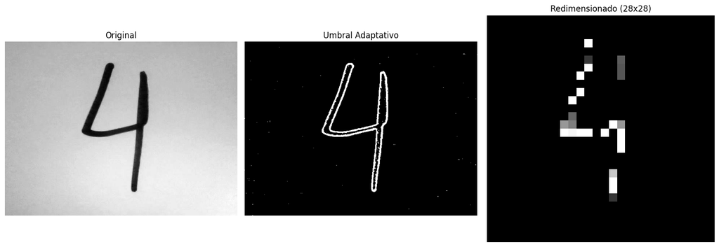

```
========================================
        Resultado de Predicción
========================================

Dígito | Probabilidad
-------------------
  0   |   0.29661
  1   |   0.03472
  2   |   0.00904
  3   |   0.00851
  4   |   0.07007
  5   |   0.14850
  6   |   0.02763
  7   |   0.00231
  8   |   0.22722
  9   |   0.17539

Predicción final: 0 (Confianza: 29.66%)
Nota: La confianza es relativamente baja (considera verificar manualmente)
```

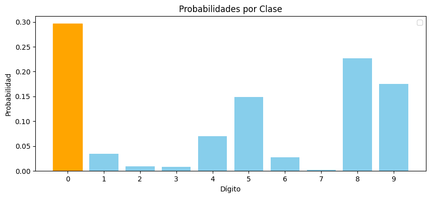

```python
import cv2
import numpy as np
import matplotlib.pyplot as plt

# 1. Cargar la imagen en escala de grises
image = cv2.imread('photo.jpg', cv2.IMREAD_GRAYSCALE)
if image is None:
    raise ValueError("No se pudo cargar la imagen. Verifica la ruta.")
############# TERCER CAMBIO   Agregar un filtro para reducir ruido y un umbradl adaptativo
##################################################################################################3
# 2. Aplicar filtro de mediana para suavizar la imagen y reducir el ruido
blurred_image = cv2.medianBlur(image, 5)  # Tamaño del filtro de mediana

# 3. Aplicar umbral adaptativo para ajustar el umbral de binarización
adaptive_thresh = cv2.adaptiveThreshold(blurred_image, 255, cv2.ADAPTIVE_THRESH_GAUSSIAN_C,
                                       cv2.THRESH_BINARY_INV, 11, 2)
##################################################################################################
# 4. Redimensionar la imagen a 28x28
resized = cv2.resize(adaptive_thresh, (28, 28))

# 5. Visualizar las imágenes
fig, axes = plt.subplots(1, 3, figsize=(15, 5))
titles = ['Original', 'Umbral Adaptativo', 'Redimensionado (28x28)']
images = [image, adaptive_thresh, resized]

for ax, img, title in zip(axes, images, titles):
    ax.imshow(img, cmap='gray')
    ax.set_title(title)
    ax.axis('off')
plt.tight_layout()
plt.show()

# 6. Preprocesamiento final (reshape y normalización)
input_image = resized.reshape(1, 28, 28).astype('float32') / 255.0  # Asegurarse de que el modelo reciba los datos normalizados

# 7. Predicción con el modelo
prediction = MOD2.predict(input_image, verbose=0)  # Usar el modelo MOD2
probabilities = prediction[0]
predicted_label = np.argmax(probabilities)
max_prob = np.max(probabilities)

# 8. Mostrar los resultados
print("\n" + "="*40)
print("Resultado de Predicción".center(40))
print("="*40)
print("\nDígito | Probabilidad")
print("-------------------")
for i, prob in enumerate(probabilities):
    print(f"  {i}   |   {prob:.5f}")

# 9. Mostrar la predicción final
confidence_color = 'green' if max_prob > 0.9 else 'orange'
print(f"\nPredicción final: {predicted_label} (Confianza: {max_prob:.2%})")
if max_prob <= 0.9:
    print("Nota: La confianza es relativamente baja (considera verificar manualmente)")

# 10. Gráfico de probabilidades
plt.figure(figsize=(10, 4))
bars = plt.bar(range(10), probabilities, color='skyblue')
bars[predicted_label].set_color(confidence_color)
plt.title('Probabilidades por Clase')
plt.xlabel('Dígito')
plt.ylabel('Probabilidad')
plt.xticks(range(10))
plt.legend()
plt.show()
```

CAMBIOS

1. Capas ocultas con BatchNorm, ReLU y Dropout Ayudo a mejorar el desempeño en la grafica de validation and train accuracy, estuve checando con GPT que capas o funciones ademas de Drop out para evitar overfitting podria agregar y menciono que juntar batch con Norm, luego puse las neuronas como lo hizo mi mejor modelo del primer taller.
2. Agregue balance de clases En las primeras versiones de la version modificada siempre me daba las mismas predicciones de que . Era 1 o 5 , ningun otro numero salia como posible prediccion, entonces decidi agregar el balance de clases y ahora minimo si salen otros numeros con una "mayor" probabilidad.
3. Agregar un filtro para reducir ruido y un umbral adaptativo de treshold Porque despues de que salieran bien las graficas y el balance, crei que el error estaba en como se procesaban las imagenes por el treshold y el resized, ahora con el adaptativo ayuda cuando la ilumancion no es la misma en toda la foto.

En si sigue fallando el modelo, de seguro ayudaria una red convolucional.

```python
# Guardar el modelo entrenado
MOD2.save('my_model.h5')
```

```
WARNING:absl:You are saving your model as an HDF5 file via `model.save()` or `keras.saving.save_model(model)`. This file format is considered legacy. We recommend using instead the native Keras format, e.g. `model.save('my_model.keras')` or `keras.saving.save_model(model, 'my_model.keras')`.
```

Doy mi palabra que he realizado esta actividad con integridad académica Para esta tarea se utilizo GPT y DEEPSEEK